# Risk Factor Analysis

## Outcome Variable

**Outcome Variable:** sstunted

## Predictor Variables

**Intervention Variable:** enwast

**Adjustment Set:**

- arm
- sex
- W_mage
- meducyrs
- feducyrs
- hhwealth_quart
- vagbrth
- W_nrooms
- brthmon
- W_parity
- impfloor
- impsan
- safeh20
- delta_W_mage
- delta_meducyrs
- delta_feducyrs
- delta_hhwealth_quart
- delta_vagbrth
- delta_W_nrooms
- delta_brthmon
- delta_W_parity
- delta_impfloor
- delta_impsan
- delta_safeh20

## Stratifying Variables

The analysis was stratified on these variable(s):

- agecat
- studyid
- country

## Data Summary

| agecat | studyid | country | enwast | sstunted | n_cell | n |
| --- | --- | --- | --- | --- | --- | --- |
| Birth | ki0047075b-MAL-ED | BANGLADESH | 0 | 0 | 200 | 241 |
| Birth | ki0047075b-MAL-ED | BANGLADESH | 0 | 1 | 1 | 241 |
| Birth | ki0047075b-MAL-ED | BANGLADESH | 1 | 0 | 40 | 241 |
| Birth | ki0047075b-MAL-ED | BANGLADESH | 1 | 1 | 0 | 241 |
| Birth | ki0047075b-MAL-ED | BRAZIL | 0 | 0 | 175 | 183 |
| Birth | ki0047075b-MAL-ED | BRAZIL | 0 | 1 | 2 | 183 |
| Birth | ki0047075b-MAL-ED | BRAZIL | 1 | 0 | 6 | 183 |
| Birth | ki0047075b-MAL-ED | BRAZIL | 1 | 1 | 0 | 183 |
| Birth | ki0047075b-MAL-ED | INDIA | 0 | 0 | 167 | 203 |
| Birth | ki0047075b-MAL-ED | INDIA | 0 | 1 | 3 | 203 |
| Birth | ki0047075b-MAL-ED | INDIA | 1 | 0 | 32 | 203 |
| Birth | ki0047075b-MAL-ED | INDIA | 1 | 1 | 1 | 203 |
| Birth | ki0047075b-MAL-ED | NEPAL | 0 | 0 | 146 | 169 |
| Birth | ki0047075b-MAL-ED | NEPAL | 0 | 1 | 2 | 169 |
| Birth | ki0047075b-MAL-ED | NEPAL | 1 | 0 | 21 | 169 |
| Birth | ki0047075b-MAL-ED | NEPAL | 1 | 1 | 0 | 169 |
| Birth | ki0047075b-MAL-ED | PERU | 0 | 0 | 271 | 279 |
| Birth | ki0047075b-MAL-ED | PERU | 0 | 1 | 2 | 279 |
| Birth | ki0047075b-MAL-ED | PERU | 1 | 0 | 6 | 279 |
| Birth | ki0047075b-MAL-ED | PERU | 1 | 1 | 0 | 279 |
| Birth | ki0047075b-MAL-ED | SOUTH AFRICA | 0 | 0 | 240 | 260 |
| Birth | ki0047075b-MAL-ED | SOUTH AFRICA | 0 | 1 | 0 | 260 |
| Birth | ki0047075b-MAL-ED | SOUTH AFRICA | 1 | 0 | 20 | 260 |
| Birth | ki0047075b-MAL-ED | SOUTH AFRICA | 1 | 1 | 0 | 260 |
| Birth | ki0047075b-MAL-ED | TANZANIA, UNITED REPUBLIC OF | 0 | 0 | 115 | 118 |
| Birth | ki0047075b-MAL-ED | TANZANIA, UNITED REPUBLIC OF | 0 | 1 | 1 | 118 |
| Birth | ki0047075b-MAL-ED | TANZANIA, UNITED REPUBLIC OF | 1 | 0 | 2 | 118 |
| Birth | ki0047075b-MAL-ED | TANZANIA, UNITED REPUBLIC OF | 1 | 1 | 0 | 118 |
| Birth | ki1000108-CMC-V-BCS-2002 | INDIA | 0 | 0 | 74 | 85 |
| Birth | ki1000108-CMC-V-BCS-2002 | INDIA | 0 | 1 | 0 | 85 |

[output cut: 314 more lines]

The following strata were considered:

- agecat: 24 months, studyid: ki0047075b-MAL-ED, country: BANGLADESH
- agecat: 24 months, studyid: ki0047075b-MAL-ED, country: BRAZIL
- agecat: 24 months, studyid: ki0047075b-MAL-ED, country: INDIA
- agecat: 24 months, studyid: ki0047075b-MAL-ED, country: NEPAL
- agecat: 24 months, studyid: ki0047075b-MAL-ED, country: PERU
- agecat: 24 months, studyid: ki0047075b-MAL-ED, country: SOUTH AFRICA
- agecat: 24 months, studyid: ki0047075b-MAL-ED, country: TANZANIA, UNITED REPUBLIC OF
- agecat: 24 months, studyid: ki1000108-CMC-V-BCS-2002, country: INDIA
- agecat: 24 months, studyid: ki1000108-IRC, country: INDIA
- agecat: 24 months, studyid: ki1017093-NIH-Birth, country: BANGLADESH
- agecat: 24 months, studyid: ki1017093b-PROVIDE, country: BANGLADESH
- agecat: 24 months, studyid: ki1017093c-NIH-Crypto, country: BANGLADESH
- agecat: 24 months, studyid: ki1066203-TanzaniaChild2, country: TANZANIA, UNITED REPUBLIC OF
- agecat: 24 months, studyid: ki1101329-Keneba, country: GAMBIA
- agecat: 24 months, studyid: ki1113344-GMS-Nepal, country: NEPAL
- agecat: 24 months, studyid: ki1114097-CMIN, country: BANGLADESH
- agecat: 24 months, studyid: ki1114097-CMIN, country: GUINEA-BISSAU
- agecat: 24 months, studyid: ki1114097-CMIN, country: PERU
- agecat: 24 months, studyid: ki1114097-CONTENT, country: PERU
- agecat: 24 months, studyid: ki1119695-PROBIT, country: BELARUS
- agecat: 24 months, studyid: ki1126311-ZVITAMBO, country: ZIMBABWE
- agecat: 24 months, studyid: ki1135781-COHORTS, country: GUATEMALA
- agecat: 24 months, studyid: ki1135781-COHORTS, country: INDIA
- agecat: 24 months, studyid: ki1135781-COHORTS, country: PHILIPPINES
- agecat: 24 months, studyid: ki1148112-LCNI-5, country: MALAWI
- agecat: 24 months, studyid: kiGH5241-JiVitA-3, country: BANGLADESH
- agecat: 24 months, studyid: kiGH5241-JiVitA-4, country: BANGLADESH
- agecat: 6 months, studyid: ki0047075b-MAL-ED, country: BANGLADESH
- agecat: 6 months, studyid: ki0047075b-MAL-ED, country: BRAZIL
- agecat: 6 months, studyid: ki0047075b-MAL-ED, country: INDIA
- agecat: 6 months, studyid: ki0047075b-MAL-ED, country: NEPAL
- agecat: 6 months, studyid: ki0047075b-MAL-ED, country: PERU
- agecat: 6 months, studyid: ki0047075b-MAL-ED, country: SOUTH AFRICA
- agecat: 6 months, studyid: ki0047075b-MAL-ED, country: TANZANIA, UNITED REPUBLIC OF
- agecat: 6 months, studyid: ki1000108-CMC-V-BCS-2002, country: INDIA
- agecat: 6 months, studyid: ki1000108-IRC, country: INDIA
- agecat: 6 months, studyid: ki1000109-EE, country: PAKISTAN
- agecat: 6 months, studyid: ki1000109-ResPak, country: PAKISTAN
- agecat: 6 months, studyid: ki1000304b-SAS-CompFeed, country: INDIA
- agecat: 6 months, studyid: ki1000304b-SAS-FoodSuppl, country: INDIA
- agecat: 6 months, studyid: ki1017093-NIH-Birth, country: BANGLADESH
- agecat: 6 months, studyid: ki1017093b-PROVIDE, country: BANGLADESH
- agecat: 6 months, studyid: ki1017093c-NIH-Crypto, country: BANGLADESH
- agecat: 6 months, studyid: ki1066203-TanzaniaChild2, country: TANZANIA, UNITED REPUBLIC OF
- agecat: 6 months, studyid: ki1101329-Keneba, country: GAMBIA
- agecat: 6 months, studyid: ki1112895-Guatemala BSC, country: GUATEMALA
- agecat: 6 months, studyid: ki1113344-GMS-Nepal, country: NEPAL
- agecat: 6 months, studyid: ki1114097-CMIN, country: BANGLADESH
- agecat: 6 months, studyid: ki1114097-CMIN, country: BRAZIL
- agecat: 6 months, studyid: ki1114097-CMIN, country: GUINEA-BISSAU
- agecat: 6 months, studyid: ki1114097-CMIN, country: PERU
- agecat: 6 months, studyid: ki1114097-CONTENT, country: PERU
- agecat: 6 months, studyid: ki1119695-PROBIT, country: BELARUS
- agecat: 6 months, studyid: ki1126311-ZVITAMBO, country: ZIMBABWE
- agecat: 6 months, studyid: ki1135781-COHORTS, country: GUATEMALA
- agecat: 6 months, studyid: ki1135781-COHORTS, country: INDIA
- agecat: 6 months, studyid: ki1135781-COHORTS, country: PHILIPPINES
- agecat: 6 months, studyid: ki1148112-LCNI-5, country: MALAWI
- agecat: 6 months, studyid: kiGH5241-JiVitA-3, country: BANGLADESH
- agecat: 6 months, studyid: kiGH5241-JiVitA-4, country: BANGLADESH
- agecat: Birth, studyid: ki0047075b-MAL-ED, country: BANGLADESH
- agecat: Birth, studyid: ki0047075b-MAL-ED, country: BRAZIL
- agecat: Birth, studyid: ki0047075b-MAL-ED, country: INDIA
- agecat: Birth, studyid: ki0047075b-MAL-ED, country: NEPAL
- agecat: Birth, studyid: ki0047075b-MAL-ED, country: PERU
- agecat: Birth, studyid: ki0047075b-MAL-ED, country: SOUTH AFRICA
- agecat: Birth, studyid: ki0047075b-MAL-ED, country: TANZANIA, UNITED REPUBLIC OF
- agecat: Birth, studyid: ki1000108-CMC-V-BCS-2002, country: INDIA
- agecat: Birth, studyid: ki1000108-IRC, country: INDIA
- agecat: Birth, studyid: ki1000109-EE, country: PAKISTAN
- agecat: Birth, studyid: ki1000109-ResPak, country: PAKISTAN
- agecat: Birth, studyid: ki1000304b-SAS-CompFeed, country: INDIA
- agecat: Birth, studyid: ki1017093-NIH-Birth, country: BANGLADESH
- agecat: Birth, studyid: ki1017093c-NIH-Crypto, country: BANGLADESH
- agecat: Birth, studyid: ki1101329-Keneba, country: GAMBIA
- agecat: Birth, studyid: ki1114097-CMIN, country: BANGLADESH
- agecat: Birth, studyid: ki1114097-CMIN, country: BRAZIL
- agecat: Birth, studyid: ki1114097-CMIN, country: PERU
- agecat: Birth, studyid: ki1114097-CONTENT, country: PERU
- agecat: Birth, studyid: ki1119695-PROBIT, country: BELARUS
- agecat: Birth, studyid: ki1126311-ZVITAMBO, country: ZIMBABWE
- agecat: Birth, studyid: ki1135781-COHORTS, country: GUATEMALA
- agecat: Birth, studyid: ki1135781-COHORTS, country: INDIA
- agecat: Birth, studyid: ki1135781-COHORTS, country: PHILIPPINES
- agecat: Birth, studyid: kiGH5241-JiVitA-3, country: BANGLADESH
- agecat: Birth, studyid: kiGH5241-JiVitA-4, country: BANGLADESH

### Dropped Strata

Some strata were dropped due to rare outcomes:

- agecat: Birth, studyid: ki0047075b-MAL-ED, country: BANGLADESH
- agecat: Birth, studyid: ki0047075b-MAL-ED, country: BRAZIL
- agecat: Birth, studyid: ki0047075b-MAL-ED, country: INDIA
- agecat: Birth, studyid: ki0047075b-MAL-ED, country: NEPAL
- agecat: Birth, studyid: ki0047075b-MAL-ED, country: PERU
- agecat: Birth, studyid: ki0047075b-MAL-ED, country: SOUTH AFRICA
- agecat: Birth, studyid: ki0047075b-MAL-ED, country: TANZANIA, UNITED REPUBLIC OF
- agecat: Birth, studyid: ki1000108-CMC-V-BCS-2002, country: INDIA
- agecat: Birth, studyid: ki1000108-IRC, country: INDIA
- agecat: Birth, studyid: ki1000109-EE, country: PAKISTAN
- agecat: Birth, studyid: ki1000109-ResPak, country: PAKISTAN
- agecat: Birth, studyid: ki1000304b-SAS-CompFeed, country: INDIA
- agecat: Birth, studyid: ki1017093-NIH-Birth, country: BANGLADESH
- agecat: Birth, studyid: ki1017093c-NIH-Crypto, country: BANGLADESH
- agecat: Birth, studyid: ki1101329-Keneba, country: GAMBIA
- agecat: Birth, studyid: ki1114097-CMIN, country: BANGLADESH
- agecat: Birth, studyid: ki1114097-CMIN, country: BRAZIL
- agecat: Birth, studyid: ki1114097-CMIN, country: PERU
- agecat: Birth, studyid: ki1114097-CONTENT, country: PERU
- agecat: Birth, studyid: ki1119695-PROBIT, country: BELARUS
- agecat: Birth, studyid: ki1126311-ZVITAMBO, country: ZIMBABWE
- agecat: Birth, studyid: ki1135781-COHORTS, country: GUATEMALA
- agecat: Birth, studyid: ki1135781-COHORTS, country: INDIA
- agecat: Birth, studyid: ki1135781-COHORTS, country: PHILIPPINES
- agecat: Birth, studyid: kiGH5241-JiVitA-3, country: BANGLADESH
- agecat: Birth, studyid: kiGH5241-JiVitA-4, country: BANGLADESH
- agecat: 6 months, studyid: ki0047075b-MAL-ED, country: BANGLADESH
- agecat: 6 months, studyid: ki0047075b-MAL-ED, country: BRAZIL
- agecat: 6 months, studyid: ki0047075b-MAL-ED, country: INDIA
- agecat: 6 months, studyid: ki0047075b-MAL-ED, country: NEPAL
- agecat: 6 months, studyid: ki0047075b-MAL-ED, country: PERU
- agecat: 6 months, studyid: ki0047075b-MAL-ED, country: SOUTH AFRICA
- agecat: 6 months, studyid: ki0047075b-MAL-ED, country: TANZANIA, UNITED REPUBLIC OF
- agecat: 6 months, studyid: ki1066203-TanzaniaChild2, country: TANZANIA, UNITED REPUBLIC OF
- agecat: 6 months, studyid: ki1112895-Guatemala BSC, country: GUATEMALA
- agecat: 6 months, studyid: ki1114097-CMIN, country: BANGLADESH
- agecat: 6 months, studyid: ki1114097-CMIN, country: BRAZIL
- agecat: 6 months, studyid: ki1114097-CMIN, country: GUINEA-BISSAU
- agecat: 6 months, studyid: ki1114097-CMIN, country: PERU
- agecat: 6 months, studyid: ki1114097-CONTENT, country: PERU
- agecat: 24 months, studyid: ki0047075b-MAL-ED, country: BRAZIL
- agecat: 24 months, studyid: ki0047075b-MAL-ED, country: NEPAL
- agecat: 24 months, studyid: ki0047075b-MAL-ED, country: PERU
- agecat: 24 months, studyid: ki0047075b-MAL-ED, country: SOUTH AFRICA
- agecat: 24 months, studyid: ki0047075b-MAL-ED, country: TANZANIA, UNITED REPUBLIC OF
- agecat: 24 months, studyid: ki1066203-TanzaniaChild2, country: TANZANIA, UNITED REPUBLIC OF
- agecat: 24 months, studyid: ki1114097-CMIN, country: PERU
- agecat: 24 months, studyid: ki1114097-CONTENT, country: PERU
- agecat: 24 months, studyid: ki1148112-LCNI-5, country: MALAWI

## Methods Detail

We’re interested in the causal parameters $E[Y_a]$ for all values of $a \in \mathcal{A}$. These parameters represent the mean outcome if, possibly contrary to fact, we intervened to set all units to have $A=a$. Under the randomization and positivity assumptions, these are identified by the statistical parameters $\psi_a=E_W[E_{Y|A,W}(Y|A=a,W)]$. In addition, we’re interested in the mean of $Y$, $E[Y]$ under no intervention (the observed mean). We will estimate these parameters by using SuperLearner to fit the relevant likelihood factors – $E_{Y|A,W}(Y|A=a,W)$ and $p(A=a|W)$, and then updating our likelihood fit using a joint TMLE.

For unadjusted analyses ($W=\{\}$), initial likelihoods were estimated using Lrnr_glm to estimate the simple $E(Y|A)$ and Lrnr_mean to estimate $p(A)$. For adjusted analyses, a small library containing Lrnr_glmnet, Lrnr_xgboost, and Lrnr_mean was used.

Having estimated these parameters, we will then use the delta method to estimate relative risks and attributable risks relative to a prespecified baseline level of $A$.

# Results Detail

## Results Plots

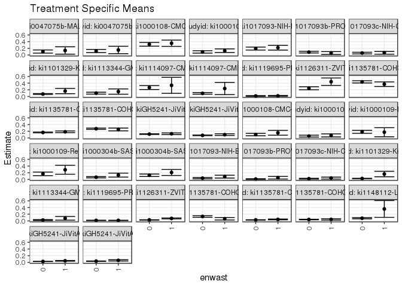

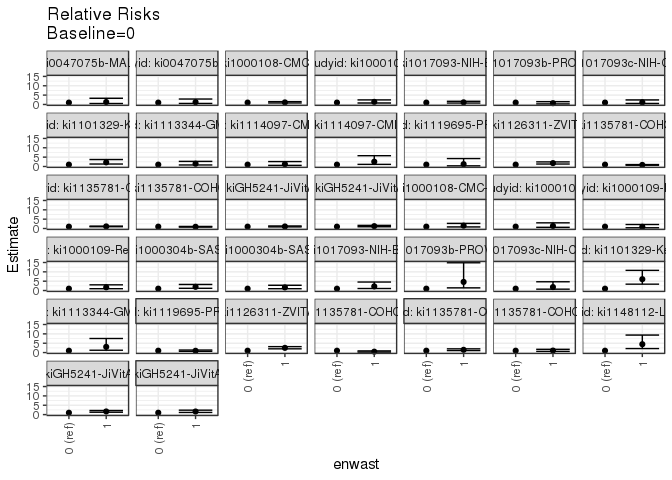

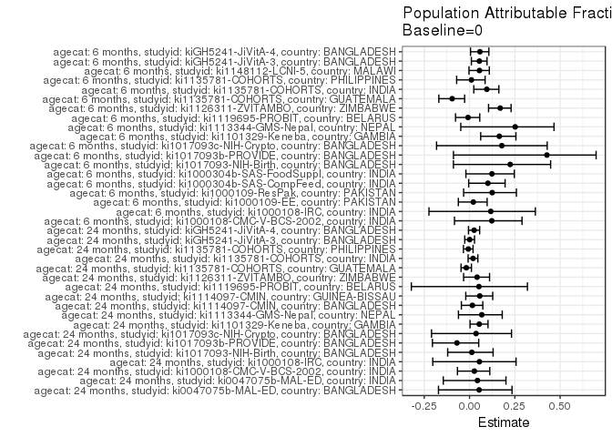

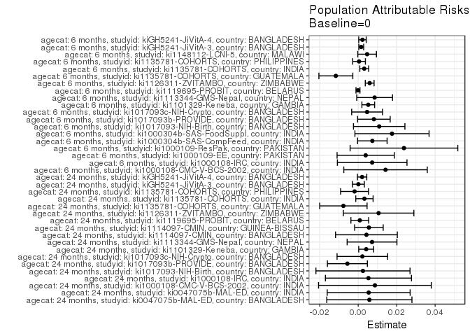

## Results Table

### Parameter: TSM

| agecat | studyid | country | intervention_level | baseline_level | estimate | ci_lower | ci_upper |
| --- | --- | --- | --- | --- | --- | --- | --- |
| 6 months | ki1000108-CMC-V-BCS-2002 | INDIA | 0 | NA | 0.1014998 | 0.0651581 | 0.1378414 |
| 6 months | ki1000108-CMC-V-BCS-2002 | INDIA | 1 | NA | 0.1546549 | 0.0826048 | 0.2267050 |
| 6 months | ki1000108-IRC | INDIA | 0 | NA | 0.0547532 | 0.0268730 | 0.0826335 |
| 6 months | ki1000108-IRC | INDIA | 1 | NA | 0.0760763 | 0.0305743 | 0.1215784 |
| 6 months | ki1000109-EE | PAKISTAN | 0 | NA | 0.1832359 | 0.1389016 | 0.2275701 |
| 6 months | ki1000109-EE | PAKISTAN | 1 | NA | 0.1716430 | 0.0354042 | 0.3078818 |
| 6 months | ki1000109-ResPak | PAKISTAN | 0 | NA | 0.1664844 | 0.1125839 | 0.2203849 |
| 6 months | ki1000109-ResPak | PAKISTAN | 1 | NA | 0.2888959 | 0.1545861 | 0.4232056 |
| 6 months | ki1000304b-SAS-CompFeed | INDIA | 0 | NA | 0.0651997 | 0.0464030 | 0.0839965 |
| 6 months | ki1000304b-SAS-CompFeed | INDIA | 1 | NA | 0.1291875 | 0.0701120 | 0.1882630 |
| 6 months | ki1000304b-SAS-FoodSuppl | INDIA | 0 | NA | 0.1245441 | 0.0878911 | 0.1611971 |
| 6 months | ki1000304b-SAS-FoodSuppl | INDIA | 1 | NA | 0.2076333 | 0.1174171 | 0.2978496 |
| 6 months | ki1017093-NIH-Birth | BANGLADESH | 0 | NA | 0.0377301 | 0.0182173 | 0.0572428 |
| 6 months | ki1017093-NIH-Birth | BANGLADESH | 1 | NA | 0.0839082 | 0.0420127 | 0.1258037 |
| 6 months | ki1017093b-PROVIDE | BANGLADESH | 0 | NA | 0.0109409 | 0.0013953 | 0.0204866 |
| 6 months | ki1017093b-PROVIDE | BANGLADESH | 1 | NA | 0.0504202 | 0.0110724 | 0.0897679 |
| 6 months | ki1017093c-NIH-Crypto | BANGLADESH | 0 | NA | 0.0213178 | 0.0088460 | 0.0337896 |
| 6 months | ki1017093c-NIH-Crypto | BANGLADESH | 1 | NA | 0.0393258 | 0.0107514 | 0.0679003 |
| 6 months | ki1101329-Keneba | GAMBIA | 0 | NA | 0.0265414 | 0.0195009 | 0.0335818 |
| 6 months | ki1101329-Keneba | GAMBIA | 1 | NA | 0.1610881 | 0.0786949 | 0.2434813 |
| 6 months | ki1113344-GMS-Nepal | NEPAL | 0 | NA | 0.0253386 | 0.0111481 | 0.0395291 |
| 6 months | ki1113344-GMS-Nepal | NEPAL | 1 | NA | 0.0773541 | 0.0224907 | 0.1322174 |
| 6 months | ki1119695-PROBIT | BELARUS | 0 | NA | 0.0154263 | 0.0097252 | 0.0211274 |
| 6 months | ki1119695-PROBIT | BELARUS | 1 | NA | 0.0147782 | 0.0091865 | 0.0203699 |
| 6 months | ki1126311-ZVITAMBO | ZIMBABWE | 0 | NA | 0.0292236 | 0.0251741 | 0.0332731 |
| 6 months | ki1126311-ZVITAMBO | ZIMBABWE | 1 | NA | 0.0735485 | 0.0600148 | 0.0870823 |
| 6 months | ki1135781-COHORTS | GUATEMALA | 0 | NA | 0.1326073 | 0.1078751 | 0.1573395 |
| 6 months | ki1135781-COHORTS | GUATEMALA | 1 | NA | 0.0638023 | 0.0274186 | 0.1001860 |
| 6 months | ki1135781-COHORTS | INDIA | 0 | NA | 0.0297514 | 0.0252191 | 0.0342837 |
| 6 months | ki1135781-COHORTS | INDIA | 1 | NA | 0.0436837 | 0.0319041 | 0.0554633 |
| 6 months | ki1135781-COHORTS | PHILIPPINES | 0 | NA | 0.0416009 | 0.0332476 | 0.0499542 |
| 6 months | ki1135781-COHORTS | PHILIPPINES | 1 | NA | 0.0441911 | 0.0241958 | 0.0641864 |
| 6 months | ki1148112-LCNI-5 | MALAWI | 0 | NA | 0.0800000 | 0.0614767 | 0.0985233 |
| 6 months | ki1148112-LCNI-5 | MALAWI | 1 | NA | 0.3571429 | 0.1059997 | 0.6082860 |
| 6 months | kiGH5241-JiVitA-3 | BANGLADESH | 0 | NA | 0.0274473 | 0.0243832 | 0.0305113 |
| 6 months | kiGH5241-JiVitA-3 | BANGLADESH | 1 | NA | 0.0457976 | 0.0348705 | 0.0567247 |
| 6 months | kiGH5241-JiVitA-4 | BANGLADESH | 0 | NA | 0.0363490 | 0.0304529 | 0.0422451 |
| 6 months | kiGH5241-JiVitA-4 | BANGLADESH | 1 | NA | 0.0598730 | 0.0404030 | 0.0793430 |
| 24 months | ki0047075b-MAL-ED | BANGLADESH | 0 | NA | 0.1036585 | 0.0568906 | 0.1504265 |
| 24 months | ki0047075b-MAL-ED | BANGLADESH | 1 | NA | 0.1351351 | 0.0247048 | 0.2455655 |
| 24 months | ki0047075b-MAL-ED | INDIA | 0 | NA | 0.1195652 | 0.0725799 | 0.1665505 |
| 24 months | ki0047075b-MAL-ED | INDIA | 1 | NA | 0.1500000 | 0.0390966 | 0.2609034 |
| 24 months | ki1000108-CMC-V-BCS-2002 | INDIA | 0 | NA | 0.3200860 | 0.2643001 | 0.3758719 |
| 24 months | ki1000108-CMC-V-BCS-2002 | INDIA | 1 | NA | 0.3521864 | 0.2580005 | 0.4463723 |
| 24 months | ki1000108-IRC | INDIA | 0 | NA | 0.0926170 | 0.0570388 | 0.1281951 |
| 24 months | ki1000108-IRC | INDIA | 1 | NA | 0.1282152 | 0.0745909 | 0.1818395 |
| 24 months | ki1017093-NIH-Birth | BANGLADESH | 0 | NA | 0.1931324 | 0.1482368 | 0.2380279 |
| 24 months | ki1017093-NIH-Birth | BANGLADESH | 1 | NA | 0.2192711 | 0.1476480 | 0.2908942 |
| 24 months | ki1017093b-PROVIDE | BANGLADESH | 0 | NA | 0.0864745 | 0.0605120 | 0.1124370 |
| 24 months | ki1017093b-PROVIDE | BANGLADESH | 1 | NA | 0.0593220 | 0.0166624 | 0.1019817 |
| 24 months | ki1017093c-NIH-Crypto | BANGLADESH | 0 | NA | 0.0578512 | 0.0338106 | 0.0818919 |
| 24 months | ki1017093c-NIH-Crypto | BANGLADESH | 1 | NA | 0.0656934 | 0.0241667 | 0.1072202 |
| 24 months | ki1101329-Keneba | GAMBIA | 0 | NA | 0.0733514 | 0.0607148 | 0.0859881 |
| 24 months | ki1101329-Keneba | GAMBIA | 1 | NA | 0.1624257 | 0.0826936 | 0.2421578 |
| 24 months | ki1113344-GMS-Nepal | NEPAL | 0 | NA | 0.0994544 | 0.0708233 | 0.1280855 |
| 24 months | ki1113344-GMS-Nepal | NEPAL | 1 | NA | 0.1471011 | 0.0679631 | 0.2262392 |
| 24 months | ki1114097-CMIN | BANGLADESH | 0 | NA | 0.2672811 | 0.2082734 | 0.3262889 |
| 24 months | ki1114097-CMIN | BANGLADESH | 1 | NA | 0.3333333 | 0.0942583 | 0.5724084 |
| 24 months | ki1114097-CMIN | GUINEA-BISSAU | 0 | NA | 0.0929791 | 0.0681626 | 0.1177956 |
| 24 months | ki1114097-CMIN | GUINEA-BISSAU | 1 | NA | 0.2380952 | 0.0557641 | 0.4204263 |
| 24 months | ki1119695-PROBIT | BELARUS | 0 | NA | 0.0150531 | 0.0003987 | 0.0297074 |
| 24 months | ki1119695-PROBIT | BELARUS | 1 | NA | 0.0186837 | 0.0061723 | 0.0311952 |
| 24 months | ki1126311-ZVITAMBO | ZIMBABWE | 0 | NA | 0.2450466 | 0.1997578 | 0.2903354 |
| 24 months | ki1126311-ZVITAMBO | ZIMBABWE | 1 | NA | 0.4417661 | 0.3299605 | 0.5535716 |
| 24 months | ki1135781-COHORTS | GUATEMALA | 0 | NA | 0.4372528 | 0.4045654 | 0.4699402 |
| 24 months | ki1135781-COHORTS | GUATEMALA | 1 | NA | 0.3678624 | 0.2995934 | 0.4361315 |
| 24 months | ki1135781-COHORTS | INDIA | 0 | NA | 0.1641923 | 0.1531453 | 0.1752393 |
| 24 months | ki1135781-COHORTS | INDIA | 1 | NA | 0.1840090 | 0.1591608 | 0.2088572 |
| 24 months | ki1135781-COHORTS | PHILIPPINES | 0 | NA | 0.2754358 | 0.2558809 | 0.2949908 |
| 24 months | ki1135781-COHORTS | PHILIPPINES | 1 | NA | 0.2541180 | 0.2128306 | 0.2954055 |
| 24 months | kiGH5241-JiVitA-3 | BANGLADESH | 0 | NA | 0.1146191 | 0.1056964 | 0.1235419 |
| 24 months | kiGH5241-JiVitA-3 | BANGLADESH | 1 | NA | 0.1253449 | 0.1009902 | 0.1496997 |
| 24 months | kiGH5241-JiVitA-4 | BANGLADESH | 0 | NA | 0.0775755 | 0.0677648 | 0.0873861 |
| 24 months | kiGH5241-JiVitA-4 | BANGLADESH | 1 | NA | 0.0984472 | 0.0733035 | 0.1235910 |

### Parameter: E(Y)

| agecat | studyid | country | intervention_level | baseline_level | estimate | ci_lower | ci_upper |
| --- | --- | --- | --- | --- | --- | --- | --- |
| 6 months | ki1000108-CMC-V-BCS-2002 | INDIA | NA | NA | 0.1157025 | 0.0827518 | 0.1486532 |
| 6 months | ki1000108-IRC | INDIA | NA | NA | 0.0620155 | 0.0379551 | 0.0860759 |
| 6 months | ki1000109-EE | PAKISTAN | NA | NA | 0.1871166 | 0.1447155 | 0.2295176 |
| 6 months | ki1000109-ResPak | PAKISTAN | NA | NA | 0.1902655 | 0.1389784 | 0.2415526 |
| 6 months | ki1000304b-SAS-CompFeed | INDIA | NA | NA | 0.0725474 | 0.0527677 | 0.0923271 |
| 6 months | ki1000304b-SAS-FoodSuppl | INDIA | NA | NA | 0.1421053 | 0.1069532 | 0.1772573 |
| 6 months | ki1017093-NIH-Birth | BANGLADESH | NA | NA | 0.0486381 | 0.0300237 | 0.0672526 |
| 6 months | ki1017093b-PROVIDE | BANGLADESH | NA | NA | 0.0190972 | 0.0079103 | 0.0302842 |
| 6 months | ki1017093c-NIH-Crypto | BANGLADESH | NA | NA | 0.0259366 | 0.0141026 | 0.0377706 |
| 6 months | ki1101329-Keneba | GAMBIA | NA | NA | 0.0317613 | 0.0242196 | 0.0393030 |
| 6 months | ki1113344-GMS-Nepal | NEPAL | NA | NA | 0.0338681 | 0.0188862 | 0.0488500 |
| 6 months | ki1119695-PROBIT | BELARUS | NA | NA | 0.0152977 | 0.0100190 | 0.0205764 |
| 6 months | ki1126311-ZVITAMBO | ZIMBABWE | NA | NA | 0.0351816 | 0.0311045 | 0.0392588 |
| 6 months | ki1135781-COHORTS | GUATEMALA | NA | NA | 0.1209767 | 0.0996719 | 0.1422815 |
| 6 months | ki1135781-COHORTS | INDIA | NA | NA | 0.0328826 | 0.0285497 | 0.0372155 |
| 6 months | ki1135781-COHORTS | PHILIPPINES | NA | NA | 0.0420363 | 0.0343109 | 0.0497616 |
| 6 months | ki1148112-LCNI-5 | MALAWI | NA | NA | 0.0846246 | 0.0657805 | 0.1034686 |
| 6 months | kiGH5241-JiVitA-3 | BANGLADESH | NA | NA | 0.0290217 | 0.0260653 | 0.0319781 |
| 6 months | kiGH5241-JiVitA-4 | BANGLADESH | NA | NA | 0.0385598 | 0.0328778 | 0.0442418 |
| 24 months | ki0047075b-MAL-ED | BANGLADESH | NA | NA | 0.1094527 | 0.0661839 | 0.1527215 |
| 24 months | ki0047075b-MAL-ED | INDIA | NA | NA | 0.1250000 | 0.0815935 | 0.1684065 |
| 24 months | ki1000108-CMC-V-BCS-2002 | INDIA | NA | NA | 0.3287671 | 0.2805081 | 0.3770261 |
| 24 months | ki1000108-IRC | INDIA | NA | NA | 0.0979381 | 0.0683249 | 0.1275514 |
| 24 months | ki1017093-NIH-Birth | BANGLADESH | NA | NA | 0.1955990 | 0.1571099 | 0.2340881 |
| 24 months | ki1017093b-PROVIDE | BANGLADESH | NA | NA | 0.0808436 | 0.0584259 | 0.1032613 |
| 24 months | ki1017093c-NIH-Crypto | BANGLADESH | NA | NA | 0.0600000 | 0.0391629 | 0.0808371 |
| 24 months | ki1101329-Keneba | GAMBIA | NA | NA | 0.0775058 | 0.0648507 | 0.0901609 |
| 24 months | ki1113344-GMS-Nepal | NEPAL | NA | NA | 0.1066398 | 0.0794767 | 0.1338030 |
| 24 months | ki1114097-CMIN | BANGLADESH | NA | NA | 0.2715517 | 0.2141972 | 0.3289063 |
| 24 months | ki1114097-CMIN | GUINEA-BISSAU | NA | NA | 0.0985401 | 0.0735635 | 0.1235168 |
| 24 months | ki1119695-PROBIT | BELARUS | NA | NA | 0.0158730 | 0.0044440 | 0.0273021 |
| 24 months | ki1126311-ZVITAMBO | ZIMBABWE | NA | NA | 0.2556391 | 0.2127831 | 0.2984951 |
| 24 months | ki1135781-COHORTS | GUATEMALA | NA | NA | 0.4295432 | 0.3992834 | 0.4598031 |
| 24 months | ki1135781-COHORTS | INDIA | NA | NA | 0.1674226 | 0.1571457 | 0.1776995 |
| 24 months | ki1135781-COHORTS | PHILIPPINES | NA | NA | 0.2735407 | 0.2555022 | 0.2915792 |
| 24 months | kiGH5241-JiVitA-3 | BANGLADESH | NA | NA | 0.1147053 | 0.1062340 | 0.1231766 |
| 24 months | kiGH5241-JiVitA-4 | BANGLADESH | NA | NA | 0.0795955 | 0.0702601 | 0.0889308 |

### Parameter: RR

| agecat | studyid | country | intervention_level | baseline_level | estimate | ci_lower | ci_upper |
| --- | --- | --- | --- | --- | --- | --- | --- |
| 6 months | ki1000108-CMC-V-BCS-2002 | INDIA | 0 | 0 | 1.0000000 | 1.0000000 | 1.000000 |
| 6 months | ki1000108-CMC-V-BCS-2002 | INDIA | 1 | 0 | 1.5236970 | 0.8466840 | 2.742053 |
| 6 months | ki1000108-IRC | INDIA | 0 | 0 | 1.0000000 | 1.0000000 | 1.000000 |
| 6 months | ki1000108-IRC | INDIA | 1 | 0 | 1.3894396 | 0.6335326 | 3.047266 |
| 6 months | ki1000109-EE | PAKISTAN | 0 | 0 | 1.0000000 | 1.0000000 | 1.000000 |
| 6 months | ki1000109-EE | PAKISTAN | 1 | 0 | 0.9367327 | 0.4086845 | 2.147055 |
| 6 months | ki1000109-ResPak | PAKISTAN | 0 | 0 | 1.0000000 | 1.0000000 | 1.000000 |
| 6 months | ki1000109-ResPak | PAKISTAN | 1 | 0 | 1.7352730 | 0.9861710 | 3.053398 |
| 6 months | ki1000304b-SAS-CompFeed | INDIA | 0 | 0 | 1.0000000 | 1.0000000 | 1.000000 |
| 6 months | ki1000304b-SAS-CompFeed | INDIA | 1 | 0 | 1.9814110 | 1.2068594 | 3.253063 |
| 6 months | ki1000304b-SAS-FoodSuppl | INDIA | 0 | 0 | 1.0000000 | 1.0000000 | 1.000000 |
| 6 months | ki1000304b-SAS-FoodSuppl | INDIA | 1 | 0 | 1.6671474 | 0.9871626 | 2.815525 |
| 6 months | ki1017093-NIH-Birth | BANGLADESH | 0 | 0 | 1.0000000 | 1.0000000 | 1.000000 |
| 6 months | ki1017093-NIH-Birth | BANGLADESH | 1 | 0 | 2.2239074 | 1.0859900 | 4.554152 |
| 6 months | ki1017093b-PROVIDE | BANGLADESH | 0 | 0 | 1.0000000 | 1.0000000 | 1.000000 |
| 6 months | ki1017093b-PROVIDE | BANGLADESH | 1 | 0 | 4.6084034 | 1.4294855 | 14.856661 |
| 6 months | ki1017093c-NIH-Crypto | BANGLADESH | 0 | 0 | 1.0000000 | 1.0000000 | 1.000000 |
| 6 months | ki1017093c-NIH-Crypto | BANGLADESH | 1 | 0 | 1.8447395 | 0.7257688 | 4.688909 |
| 6 months | ki1101329-Keneba | GAMBIA | 0 | 0 | 1.0000000 | 1.0000000 | 1.000000 |
| 6 months | ki1101329-Keneba | GAMBIA | 1 | 0 | 6.0693208 | 3.4121415 | 10.795758 |
| 6 months | ki1113344-GMS-Nepal | NEPAL | 0 | 0 | 1.0000000 | 1.0000000 | 1.000000 |
| 6 months | ki1113344-GMS-Nepal | NEPAL | 1 | 0 | 3.0528201 | 1.2378924 | 7.528692 |
| 6 months | ki1119695-PROBIT | BELARUS | 0 | 0 | 1.0000000 | 1.0000000 | 1.000000 |
| 6 months | ki1119695-PROBIT | BELARUS | 1 | 0 | 0.9579844 | 0.6756059 | 1.358387 |
| 6 months | ki1126311-ZVITAMBO | ZIMBABWE | 0 | 0 | 1.0000000 | 1.0000000 | 1.000000 |
| 6 months | ki1126311-ZVITAMBO | ZIMBABWE | 1 | 0 | 2.5167529 | 1.9997642 | 3.167396 |
| 6 months | ki1135781-COHORTS | GUATEMALA | 0 | 0 | 1.0000000 | 1.0000000 | 1.000000 |
| 6 months | ki1135781-COHORTS | GUATEMALA | 1 | 0 | 0.4811372 | 0.2641978 | 0.876211 |
| 6 months | ki1135781-COHORTS | INDIA | 0 | 0 | 1.0000000 | 1.0000000 | 1.000000 |
| 6 months | ki1135781-COHORTS | INDIA | 1 | 0 | 1.4682902 | 1.0782766 | 1.999372 |
| 6 months | ki1135781-COHORTS | PHILIPPINES | 0 | 0 | 1.0000000 | 1.0000000 | 1.000000 |
| 6 months | ki1135781-COHORTS | PHILIPPINES | 1 | 0 | 1.0622623 | 0.6476119 | 1.742403 |
| 6 months | ki1148112-LCNI-5 | MALAWI | 0 | 0 | 1.0000000 | 1.0000000 | 1.000000 |
| 6 months | ki1148112-LCNI-5 | MALAWI | 1 | 0 | 4.4642857 | 2.1292496 | 9.360033 |
| 6 months | kiGH5241-JiVitA-3 | BANGLADESH | 0 | 0 | 1.0000000 | 1.0000000 | 1.000000 |
| 6 months | kiGH5241-JiVitA-3 | BANGLADESH | 1 | 0 | 1.6685670 | 1.2781969 | 2.178159 |
| 6 months | kiGH5241-JiVitA-4 | BANGLADESH | 0 | 0 | 1.0000000 | 1.0000000 | 1.000000 |
| 6 months | kiGH5241-JiVitA-4 | BANGLADESH | 1 | 0 | 1.6471695 | 1.1471599 | 2.365117 |
| 24 months | ki0047075b-MAL-ED | BANGLADESH | 0 | 0 | 1.0000000 | 1.0000000 | 1.000000 |
| 24 months | ki0047075b-MAL-ED | BANGLADESH | 1 | 0 | 1.3036566 | 0.5125857 | 3.315583 |
| 24 months | ki0047075b-MAL-ED | INDIA | 0 | 0 | 1.0000000 | 1.0000000 | 1.000000 |
| 24 months | ki0047075b-MAL-ED | INDIA | 1 | 0 | 1.2545455 | 0.5430650 | 2.898151 |
| 24 months | ki1000108-CMC-V-BCS-2002 | INDIA | 0 | 0 | 1.0000000 | 1.0000000 | 1.000000 |
| 24 months | ki1000108-CMC-V-BCS-2002 | INDIA | 1 | 0 | 1.1002869 | 0.8007996 | 1.511778 |
| 24 months | ki1000108-IRC | INDIA | 0 | 0 | 1.0000000 | 1.0000000 | 1.000000 |
| 24 months | ki1000108-IRC | INDIA | 1 | 0 | 1.3843595 | 0.7830701 | 2.447356 |
| 24 months | ki1017093-NIH-Birth | BANGLADESH | 0 | 0 | 1.0000000 | 1.0000000 | 1.000000 |
| 24 months | ki1017093-NIH-Birth | BANGLADESH | 1 | 0 | 1.1353410 | 0.7602193 | 1.695562 |
| 24 months | ki1017093b-PROVIDE | BANGLADESH | 0 | 0 | 1.0000000 | 1.0000000 | 1.000000 |
| 24 months | ki1017093b-PROVIDE | BANGLADESH | 1 | 0 | 0.6860061 | 0.3146966 | 1.495423 |
| 24 months | ki1017093c-NIH-Crypto | BANGLADESH | 0 | 0 | 1.0000000 | 1.0000000 | 1.000000 |
| 24 months | ki1017093c-NIH-Crypto | BANGLADESH | 1 | 0 | 1.1355579 | 0.5329294 | 2.419629 |
| 24 months | ki1101329-Keneba | GAMBIA | 0 | 0 | 1.0000000 | 1.0000000 | 1.000000 |
| 24 months | ki1101329-Keneba | GAMBIA | 1 | 0 | 2.2143486 | 1.3166680 | 3.724052 |
| 24 months | ki1113344-GMS-Nepal | NEPAL | 0 | 0 | 1.0000000 | 1.0000000 | 1.000000 |
| 24 months | ki1113344-GMS-Nepal | NEPAL | 1 | 0 | 1.4790810 | 0.8040495 | 2.720828 |
| 24 months | ki1114097-CMIN | BANGLADESH | 0 | 0 | 1.0000000 | 1.0000000 | 1.000000 |
| 24 months | ki1114097-CMIN | BANGLADESH | 1 | 0 | 1.2471264 | 0.5888451 | 2.641313 |
| 24 months | ki1114097-CMIN | GUINEA-BISSAU | 0 | 0 | 1.0000000 | 1.0000000 | 1.000000 |
| 24 months | ki1114097-CMIN | GUINEA-BISSAU | 1 | 0 | 2.5607386 | 1.1380602 | 5.761894 |
| 24 months | ki1119695-PROBIT | BELARUS | 0 | 0 | 1.0000000 | 1.0000000 | 1.000000 |
| 24 months | ki1119695-PROBIT | BELARUS | 1 | 0 | 1.2411912 | 0.3633972 | 4.239315 |
| 24 months | ki1126311-ZVITAMBO | ZIMBABWE | 0 | 0 | 1.0000000 | 1.0000000 | 1.000000 |
| 24 months | ki1126311-ZVITAMBO | ZIMBABWE | 1 | 0 | 1.8027838 | 1.3170850 | 2.467593 |
| 24 months | ki1135781-COHORTS | GUATEMALA | 0 | 0 | 1.0000000 | 1.0000000 | 1.000000 |
| 24 months | ki1135781-COHORTS | GUATEMALA | 1 | 0 | 0.8413038 | 0.6893809 | 1.026707 |
| 24 months | ki1135781-COHORTS | INDIA | 0 | 0 | 1.0000000 | 1.0000000 | 1.000000 |
| 24 months | ki1135781-COHORTS | INDIA | 1 | 0 | 1.1206919 | 0.9653548 | 1.301025 |
| 24 months | ki1135781-COHORTS | PHILIPPINES | 0 | 0 | 1.0000000 | 1.0000000 | 1.000000 |
| 24 months | ki1135781-COHORTS | PHILIPPINES | 1 | 0 | 0.9226035 | 0.7737008 | 1.100163 |
| 24 months | kiGH5241-JiVitA-3 | BANGLADESH | 0 | 0 | 1.0000000 | 1.0000000 | 1.000000 |
| 24 months | kiGH5241-JiVitA-3 | BANGLADESH | 1 | 0 | 1.0935777 | 0.8878266 | 1.347011 |
| 24 months | kiGH5241-JiVitA-4 | BANGLADESH | 0 | 0 | 1.0000000 | 1.0000000 | 1.000000 |
| 24 months | kiGH5241-JiVitA-4 | BANGLADESH | 1 | 0 | 1.2690515 | 0.9576620 | 1.681691 |

### Parameter: PAR

| agecat | studyid | country | intervention_level | baseline_level | estimate | ci_lower | ci_upper |
| --- | --- | --- | --- | --- | --- | --- | --- |
| 6 months | ki1000108-CMC-V-BCS-2002 | INDIA | 0 | NA | 0.0142027 | -0.0074965 | 0.0359020 |
| 6 months | ki1000108-IRC | INDIA | 0 | NA | 0.0072623 | -0.0108319 | 0.0253564 |
| 6 months | ki1000109-EE | PAKISTAN | 0 | NA | 0.0038807 | -0.0109905 | 0.0187519 |
| 6 months | ki1000109-ResPak | PAKISTAN | 0 | NA | 0.0237811 | -0.0042147 | 0.0517769 |
| 6 months | ki1000304b-SAS-CompFeed | INDIA | 0 | NA | 0.0073477 | -0.0003210 | 0.0150163 |
| 6 months | ki1000304b-SAS-FoodSuppl | INDIA | 0 | NA | 0.0175612 | -0.0017153 | 0.0368377 |
| 6 months | ki1017093-NIH-Birth | BANGLADESH | 0 | NA | 0.0109081 | -0.0024658 | 0.0242819 |
| 6 months | ki1017093b-PROVIDE | BANGLADESH | 0 | NA | 0.0081563 | -0.0003100 | 0.0166226 |
| 6 months | ki1017093c-NIH-Crypto | BANGLADESH | 0 | NA | 0.0046188 | -0.0033992 | 0.0126368 |
| 6 months | ki1101329-Keneba | GAMBIA | 0 | NA | 0.0052199 | 0.0019086 | 0.0085313 |
| 6 months | ki1113344-GMS-Nepal | NEPAL | 0 | NA | 0.0085295 | -0.0007698 | 0.0178288 |
| 6 months | ki1119695-PROBIT | BELARUS | 0 | NA | -0.0001286 | -0.0011644 | 0.0009072 |
| 6 months | ki1126311-ZVITAMBO | ZIMBABWE | 0 | NA | 0.0059581 | 0.0036722 | 0.0082439 |
| 6 months | ki1135781-COHORTS | GUATEMALA | 0 | NA | -0.0116306 | -0.0204474 | -0.0028138 |
| 6 months | ki1135781-COHORTS | INDIA | 0 | NA | 0.0031312 | 0.0008204 | 0.0054420 |
| 6 months | ki1135781-COHORTS | PHILIPPINES | 0 | NA | 0.0004353 | -0.0028641 | 0.0037348 |
| 6 months | ki1148112-LCNI-5 | MALAWI | 0 | NA | 0.0046246 | -0.0002164 | 0.0094655 |
| 6 months | kiGH5241-JiVitA-3 | BANGLADESH | 0 | NA | 0.0015744 | 0.0003111 | 0.0028378 |
| 6 months | kiGH5241-JiVitA-4 | BANGLADESH | 0 | NA | 0.0022108 | 0.0002681 | 0.0041535 |
| 24 months | ki0047075b-MAL-ED | BANGLADESH | 0 | NA | 0.0057942 | -0.0163463 | 0.0279347 |
| 24 months | ki0047075b-MAL-ED | INDIA | 0 | NA | 0.0054348 | -0.0161277 | 0.0269973 |
| 24 months | ki1000108-CMC-V-BCS-2002 | INDIA | 0 | NA | 0.0086811 | -0.0206225 | 0.0379848 |
| 24 months | ki1000108-IRC | INDIA | 0 | NA | 0.0053212 | -0.0170542 | 0.0276965 |
| 24 months | ki1017093-NIH-Birth | BANGLADESH | 0 | NA | 0.0024667 | -0.0220026 | 0.0269359 |
| 24 months | ki1017093b-PROVIDE | BANGLADESH | 0 | NA | -0.0056309 | -0.0160268 | 0.0047650 |
| 24 months | ki1017093c-NIH-Crypto | BANGLADESH | 0 | NA | 0.0021488 | -0.0110023 | 0.0152998 |
| 24 months | ki1101329-Keneba | GAMBIA | 0 | NA | 0.0041544 | 0.0002647 | 0.0080441 |
| 24 months | ki1113344-GMS-Nepal | NEPAL | 0 | NA | 0.0071854 | -0.0057594 | 0.0201302 |
| 24 months | ki1114097-CMIN | BANGLADESH | 0 | NA | 0.0042706 | -0.0117879 | 0.0203291 |
| 24 months | ki1114097-CMIN | GUINEA-BISSAU | 0 | NA | 0.0055610 | -0.0018669 | 0.0129890 |
| 24 months | ki1119695-PROBIT | BELARUS | 0 | NA | 0.0008200 | -0.0037993 | 0.0054392 |
| 24 months | ki1126311-ZVITAMBO | ZIMBABWE | 0 | NA | 0.0105925 | -0.0077556 | 0.0289405 |
| 24 months | ki1135781-COHORTS | GUATEMALA | 0 | NA | -0.0077096 | -0.0200229 | 0.0046037 |
| 24 months | ki1135781-COHORTS | INDIA | 0 | NA | 0.0032303 | -0.0012720 | 0.0077326 |
| 24 months | ki1135781-COHORTS | PHILIPPINES | 0 | NA | -0.0018951 | -0.0091472 | 0.0053569 |
| 24 months | kiGH5241-JiVitA-3 | BANGLADESH | 0 | NA | 0.0000861 | -0.0030089 | 0.0031811 |
| 24 months | kiGH5241-JiVitA-4 | BANGLADESH | 0 | NA | 0.0020200 | -0.0004071 | 0.0044472 |

### Parameter: PAF

| agecat | studyid | country | intervention_level | baseline_level | estimate | ci_lower | ci_upper |
| --- | --- | --- | --- | --- | --- | --- | --- |
| 6 months | ki1000108-CMC-V-BCS-2002 | INDIA | 0 | NA | 0.1227521 | -0.0832239 | 0.2895615 |
| 6 months | ki1000108-IRC | INDIA | 0 | NA | 0.1171039 | -0.2241929 | 0.3632494 |
| 6 months | ki1000109-EE | PAKISTAN | 0 | NA | 0.0207394 | -0.0619847 | 0.0970197 |
| 6 months | ki1000109-ResPak | PAKISTAN | 0 | NA | 0.1249890 | -0.0327317 | 0.2586223 |
| 6 months | ki1000304b-SAS-CompFeed | INDIA | 0 | NA | 0.1012808 | -0.0049115 | 0.1962513 |
| 6 months | ki1000304b-SAS-FoodSuppl | INDIA | 0 | NA | 0.1235787 | -0.0201826 | 0.2470816 |
| 6 months | ki1017093-NIH-Birth | BANGLADESH | 0 | NA | 0.2242699 | -0.0890629 | 0.4474541 |
| 6 months | ki1017093b-PROVIDE | BANGLADESH | 0 | NA | 0.4270937 | -0.0888394 | 0.6985583 |
| 6 months | ki1017093c-NIH-Crypto | BANGLADESH | 0 | NA | 0.1780792 | -0.1821916 | 0.4285582 |
| 6 months | ki1101329-Keneba | GAMBIA | 0 | NA | 0.1643489 | 0.0614584 | 0.2559597 |
| 6 months | ki1113344-GMS-Nepal | NEPAL | 0 | NA | 0.2518458 | -0.0484628 | 0.4661377 |
| 6 months | ki1119695-PROBIT | BELARUS | 0 | NA | -0.0084066 | -0.0774922 | 0.0562495 |
| 6 months | ki1126311-ZVITAMBO | ZIMBABWE | 0 | NA | 0.1693515 | 0.1048314 | 0.2292213 |
| 6 months | ki1135781-COHORTS | GUATEMALA | 0 | NA | -0.0961395 | -0.1697242 | -0.0271838 |
| 6 months | ki1135781-COHORTS | INDIA | 0 | NA | 0.0952239 | 0.0233653 | 0.1617952 |
| 6 months | ki1135781-COHORTS | PHILIPPINES | 0 | NA | 0.0103563 | -0.0713229 | 0.0858083 |
| 6 months | ki1148112-LCNI-5 | MALAWI | 0 | NA | 0.0546479 | -0.0031785 | 0.1091410 |
| 6 months | kiGH5241-JiVitA-3 | BANGLADESH | 0 | NA | 0.0542501 | 0.0100699 | 0.0964586 |
| 6 months | kiGH5241-JiVitA-4 | BANGLADESH | 0 | NA | 0.0573343 | 0.0053577 | 0.1065947 |
| 24 months | ki0047075b-MAL-ED | BANGLADESH | 0 | NA | 0.0529379 | -0.1715422 | 0.2344052 |
| 24 months | ki0047075b-MAL-ED | INDIA | 0 | NA | 0.0434783 | -0.1449793 | 0.2009167 |
| 24 months | ki1000108-CMC-V-BCS-2002 | INDIA | 0 | NA | 0.0264051 | -0.0669130 | 0.1115611 |
| 24 months | ki1000108-IRC | INDIA | 0 | NA | 0.0543321 | -0.2030789 | 0.2566674 |
| 24 months | ki1017093-NIH-Birth | BANGLADESH | 0 | NA | 0.0126108 | -0.1206899 | 0.1300561 |
| 24 months | ki1017093b-PROVIDE | BANGLADESH | 0 | NA | -0.0696520 | -0.2049603 | 0.0504622 |
| 24 months | ki1017093c-NIH-Crypto | BANGLADESH | 0 | NA | 0.0358127 | -0.2098968 | 0.2316227 |
| 24 months | ki1101329-Keneba | GAMBIA | 0 | NA | 0.0536009 | 0.0027217 | 0.1018843 |
| 24 months | ki1113344-GMS-Nepal | NEPAL | 0 | NA | 0.0673804 | -0.0612590 | 0.1804269 |
| 24 months | ki1114097-CMIN | BANGLADESH | 0 | NA | 0.0157267 | -0.0451956 | 0.0730980 |
| 24 months | ki1114097-CMIN | GUINEA-BISSAU | 0 | NA | 0.0564340 | -0.0208643 | 0.1278795 |
| 24 months | ki1119695-PROBIT | BELARUS | 0 | NA | 0.0516569 | -0.3213434 | 0.3193634 |
| 24 months | ki1126311-ZVITAMBO | ZIMBABWE | 0 | NA | 0.0414353 | -0.0328735 | 0.1103981 |
| 24 months | ki1135781-COHORTS | GUATEMALA | 0 | NA | -0.0179483 | -0.0470483 | 0.0103430 |
| 24 months | ki1135781-COHORTS | INDIA | 0 | NA | 0.0192943 | -0.0079456 | 0.0457980 |
| 24 months | ki1135781-COHORTS | PHILIPPINES | 0 | NA | -0.0069281 | -0.0337882 | 0.0192341 |
| 24 months | kiGH5241-JiVitA-3 | BANGLADESH | 0 | NA | 0.0007508 | -0.0265972 | 0.0273704 |
| 24 months | kiGH5241-JiVitA-4 | BANGLADESH | 0 | NA | 0.0253787 | -0.0059623 | 0.0557432 |